# Living small in the city or large in the ’burbs?

## MVP Summary

#### Katherine Chandler, K2 Exploratory Data Analysis

## Background

The small home movement suggests that small urban homes are a better asset than large suburban homes, but is this economic reality? Is a small urban home *really* a better investment than a large suburban home? This question was addressed using current and historical real estate prices for the Salt Lake City area obtained from the real estate market place Zillow.

## Questions for Exploration

This question was addressed as three discrete sub-questions:

- Are small homes more valuable (per square foot) than large homes?
- Is a small home downtown really more valuable than a large home in the ’burbs?
- Has the relative value of small urban homes increased more than that of large suburban homes?

#### Question 1. Are small homes more valuable (per square foot) than large homes?

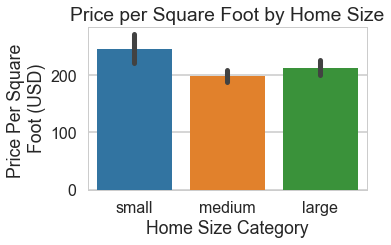

**Figure 1. Price per Square Foot by Home Size**

The mean price per square foot for a home less than 1200 sqft (‘small’) is $249, greater than that of either ‘medium’ sized homes ($195) or ‘large’ homes ($208). **Relative to their size, small homes are more valuable than large homes**.

#### Question 2: Is a small home downtown really more valuable than a large home in the ’burbs?

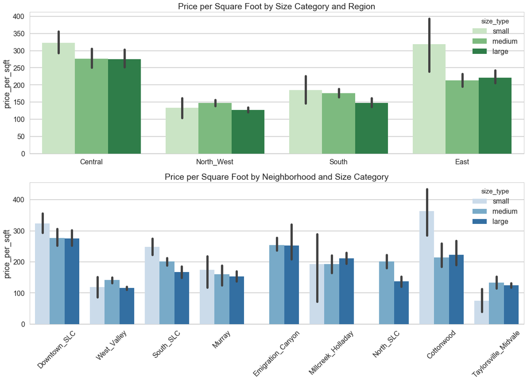

**Figure 2. Price per Square Foot by Size Category and Region**

**Yes, a small home downtown is more valuable (relative to size) than a large house in the suburbs.** The median price per square foot for a small home in Central Salt Lake is $323 while large homes in East, North-West-SLC, and South are priced at $222, $128, and $148, respectively.

While a small home downtown is more valuable than a large home in the suburbs, a small home in Downtown-SLC is *not* more valuable (per square foot) than a small home in an eastern suburb. In fact, the most valuable asset type in this data is a small home in the suburb of Cottonwood, with a median price per square foot of $364.

#### Question 3: Has the relative value of small urban homes increased more than that of large suburban homes?

The normalized Zillow Home Value Index (ZHVI) was plotted for small homes downtown versus large homes in each of the three suburban regions.

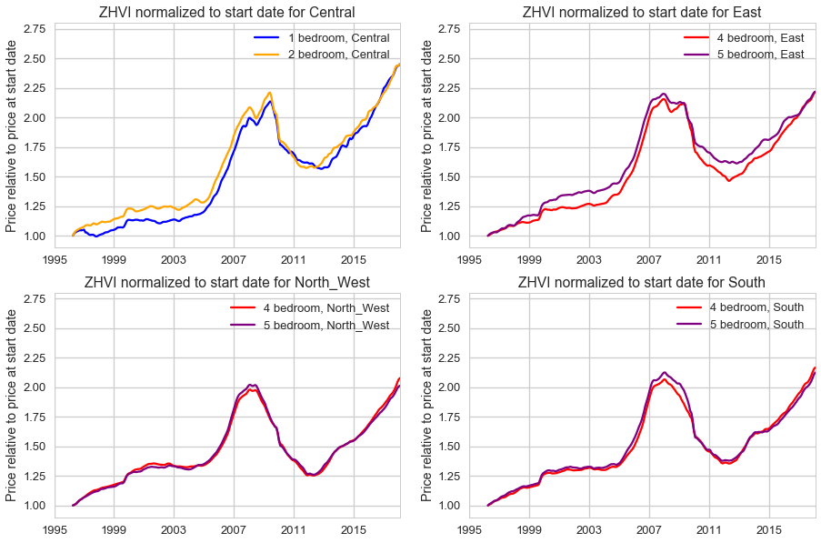

**Figure 3. Historical Prices for Small Urban Homes and Large Suburban Homes**

This data shows that in addition to being a less volitile investment, the relative value of small urban homes has appreciated more than that of large suburban homes, particularly in less desirable neighborhoods like North-West and South Salt Lake City. The 2018 data shows small homes at their highest valuation since 1996, while large suburban homes are appreciated to roughly the same valuation as during the 2006-2008 bubble.

Is it better to own a small home downtown than a large home in the suburbs? The answer undoubtably depends on the specific suburb and the market trajectory, but in the context of Salt Lake City and the current market boom I will give this question a **‘probably’ yes**. Small urban homes are rapidly appreciating and are likely to maintain value well in the next downturn.

## Summary

- Are small homes more valuable (per square foot) than large homes?

  **Yes.**
- Is a small home downtown really more valuable than a large home in the ’burbs?

  **Yes, but surprisingly a small home in a fancy suburb is worth more!**
- Has the relative value of small urban homes increased more rapidly than that of larger suburban homes?

  **Probably yes. During this current market bubble, small urban homes have appreciated to their highest value since 1996 and surpassed the relative appreciation of large suburban homes. Additionally, price behavior in past downturns indicate that urban homes (small and otherwise) maintain their value better than other property types during market corrections.**

These findings are mixed for the small house people. Small urban homes do hold their value well and in the current market are appreciating quickly, but for prospective buyers small homes come with a high price per square foot. I am satisfied that small urban homes are a stable investment, but I suppose I’ll have to keep an open mind about Salt Lake City’s eastern suburbs.

## Limitations and Further Exploration

- These data do not include actual sales price data, which is not publically available in the state of Utah.
- The historical price data is not complete for all ZIP codes and home types in this analysis.
- Further analysis could explore the year-over-year rate of change for ZHVI and add additional category classifiers, such as condo/ single family, the age of the home, the lot size, and neighborhood demographic features.